# ANÁLISIS Y PREDICCIÓN DE DISTRIBUCIÓN TRONCAL DE ENERGÍA

## Práctico de Análisis y Visualización

- Gabriel Moyano
- Leonardo Rebola
- Pablo Leiva

### Análisis descriptivo

- Entender qué tipos de features poseen los dataset, cómo se relacionan entre ellos.
- Identificar features objetivo.

En el dataset de energia encontramos que **Kwatts 3 fases** es nuestra variable principal. Es resultado de las demas y podría calcularse ya que potencia es el resultado del producto entre la corriente y la tensión. Esto ultimo también nos habla de la relación entre las variables.

El features objetivo del dataset energia es **Kwatts 3 fases** y del dataset clima son la **temperatura** y el **viento**.

### Análisis estadístico

- Ordenar temporalmente los dataset.
- Seleccionar al menos 3 features relevantes para el problema. Utilizar los gráficos y cálculos que le parezcan más apropiados para llegar a las conclusiones.

**¿Existen outliers para estos features?**

- Si existen outliers muy dispersos con respecto la mediana impactando en un rango muy grande y en la media.

**¿Hay valores faltantes?**

- Si, hay valores NaN y valores en 0.0

**¿Hay valores negativos?**

- Si, hay valores negativos. Se ha decidido convertirlos en positivos considerando que el **Factor de Potencia** por definición es un valor entre 0 y 1. Generalmente con un valor de entre 0,85 y 1 según lo que investigamos. Nos encontramos en el dataset que esta variable a veces es negativa pero siempre dentro de su rango. Por lo cual comparando cuando esta se vuelve negativa tambien lo hace **Kwatts 3 fases**, nuestra feature relevante. Entonces la conclusion fue aplicarle valor absoluto.

**¿Que decisión tomarían para completar o eliminar estos outliers y faltantes?**

- Ya con los valores convertidos a positivos y sabiendo que nuestro valor minimo posible es cero, este significando un corte de energia implica que no podemos eliminarlo. Por lo tanto tenemos si miramos la mediana: Lo que esta muy por arriba lo consideramos outliers -los eliminamos- y lo que esta muy por debajo lo consideramos cero -corte de energia-. Hay valores muy cercanos a cero que para simplificar el análisis los consideramos nulos entendiendolos como cortes del servicio. Más formalmente nuestro corte para los outliers lo realizamos a distancia de 2 veces un intervalo de confianza desde la mediana y donde el intervalo de confianza lo tomamos como la distancia entre el primer y tercer cuartil.
- Por el lado de la temperatura, lo que decidimos hacer para completar rangos horarios en periodos de 5 minutos -para igualar al otro dataset- es usar interpolación de valores pero estoy introduce mucho error al momento de hacer el análisis de correlaciones por esto lo dejamos con los valores originales. Por otro lado también realizamos el análisis de valores outliers de manera similar al realizado los datos de la potencia total.

**¿Cómo es la distribución de las variables en el dataset?**

- De los datos observados parece que la temperatura y la velocidad del viento poseen distribuciones similares a las de tipo normal y de tipo Weibull (que sería lo esperable de manera general). Para el caso de la variable de potencia presenta una distribución bimodal, donde aparecen algunas mediciones alrededor de 0 (suponemos que por cortes del servicio) y por otro lado una distribución no simética con una cola hacia la derecha.

**¿Se observa alguna estacionalidad?**

- Se observa desde el comienzo de la curantena una reducción en los picos de consumo.

**¿Existe correlación entre las variables? ¿Que variables se correlacionan más con la potencia distribuida?**

- A priori por el gráfico parece observarse una correlación positiva entre la potencia total y la temperatura. Los cortes del servicio no parecen estár relacionados con altas temperaturas ni con altas velocidades de viento en los datos observados. Ademas realizamos un análisis mediante el coeficiente de Spearman para comparar la correlaciones entre 2 de las variables. Este índice nos indicaría el nivel de correlación, si su valor es próximo a -1 o 1 sugeriría mayor grado de correlación. El coeficientes de Separman entre las variables de potencia y temperatura es aproximadamente rho = 0.623, entre las variables de potencia y velocidad de viento es aproximadamente rho = 0.003 y entre las variables de temperatura y velocidad de viento es aproximadamente rho = 0.284.

**Calidad del servicio:**

- Los cortes de energía se han dado únicamente en los meses de verano, con mayor incidencia en diciembre, seguido de enero y luego febrero. Con un total de 745 minutos de cortes para diciembre, 460 minutos en enero y 405 minutos para febrero. En cuanto a la duración de los cortes, su mediana es de 5 minutos y su media de 17,9 minutos. Se han presentado poco cortes de energía prolongados: dos en enero y uno para diciembre y febrero. Los cuales están entre 110 y 330 minutos de duración. Las franjas con más interrupciones de servicio son de 6:00 a 12:00hs y de 18:00 a 24:00hs. Siendo las 11:00 la hora con mayor frecuencia de cortes, seguido por las 21:00 y 22:00hs.

**Causas de corte de servicio:**

- Analizar que sucede con los demás features al momento de una corte.
- Se observa alguna relación con la temperatura y velocidad/dirección del viento en estos períodos?
  - Se pueden observar problemas con los datos en el mes de diciembre, aunque esto se puede deber a la nueva implementación del sistema de toma de datos. También se observan algunos cortes luego del aumento de temperatura en el mes de enero y los cortes parecen ser independientes de la velocidad del viento.
- Analizar el comportamiento de la distribución semalmente, es comparable mes a mes? La distribución de potencia, ¿se asemeja a alguna conocida?
  - Realizando un análisis de los datos en periodos de semanas podemos concluir que las distribuciones de estas variables y sus correlaciones son comparables semana tras semana. Analizando el cambio temporal de las medias por semana podemos hacer las siguientes observaciones respecto a las variables:
    - Potencia total:
      - Se nota un nivel bajo durante el comienzo de diciembre (posiblemente por cortes o por problemas del sistema de medición)
      - Se observa que se estabiliza en un valor más bajo a la media desde la semana en la que se declara la cuarentena obligatoria.
    - Temperatura:
      - Se observa un leve descenso en las medias de las temperaturas a medida que se toman datos en las semanas posteriores al verano.
    - Velocidad del viento:
      - No se observan mayores cambios en las medias semanales durante todo el periodo de tiempo

```python
from IPython.display import display, Markdown


def display_markdown(*args, **kwargs):
    return display(Markdown(*args, **kwargs))

# Importación de las librerías necesarias
import numpy as np
import pandas as pd
import matplotlib as mpl
mpl.get_cachedir()
import matplotlib.pyplot as plt
%matplotlib inline
import seaborn as sns
import datetime as dt
import warnings

pd.set_option('display.max_columns', 150)
pd.set_option('display.max_rows', 150)
pd.set_option('max_colwidth', 151)
# Quitamos notacion cientifica de los float
pd.set_option('display.float_format', lambda x: '%.3f' % x)
warnings.filterwarnings('ignore')

#Parsing auxiliar
dateparse = lambda x: dt.datetime.strptime(x, '%Y-%m-%d %H:%M:%S')

# Colores
BLUE = '#35A7FF'
RED = '#FF5964'
GREEN = '#6BF178'
YELLOW = '#FFE74C'
```

# Analisis Energia

### Carga del dataset

```python
# _ds_energía
_ds_energia = pd.read_csv('https://raw.githubusercontent.com/alaain04/diplodatos/master/data/distribucion.csv',
                          dtype={'Amper fase T-A': float},
                          parse_dates=['Fecha'],
                          date_parser=dateparse,
                          float_precision='round_trip')

# renombrado de columnas
_ds_energia.columns = ['fecha','ta','sa','ra','vab','vca','vbc','kwatts','potencia']
_ds_energia.columns
```

```
Index(['fecha', 'ta', 'sa', 'ra', 'vab', 'vca', 'vbc', 'kwatts', 'potencia'], dtype='object')
```

### Observacion de datos

```python
# Observamos los primeros y ultimos valores del dataset ordenados por fecha

_ds_energia = _ds_energia.sort_values(by='fecha')
_ds_energia
```

|  | fecha | ta | sa | ra | vab | vca | vbc | kwatts | potencia |
| --- | --- | --- | --- | --- | --- | --- | --- | --- | --- |
| 36351 | 2019-12-03 20:45:00 | 11.000 | 11.000 | 12.000 | 2147483.650 | 42.160 | 40.940 | -2147483647.000 | 0.000 |
| 36352 | 2019-12-03 20:50:00 | 11.000 | 11.000 | 11.000 | 0.000 | 2147483.650 | 0.000 | -2147483647.000 | 0.000 |
| 36353 | 2019-12-03 20:55:00 | 11.000 | 11.000 | 12.000 | 2147483.650 | 2147483.650 | 2147483.650 | -2147483647.000 | -0.930 |
| 36354 | 2019-12-03 21:00:00 | 11.000 | 11.000 | 11.000 | 2147483.650 | 0.000 | 2147483.650 | 0.000 | 0.000 |
| 36355 | 2019-12-03 21:05:00 | 10.000 | 10.000 | 11.000 | 35.780 | 36.540 | 0.000 | -4342.000 | -0.510 |
| ... | ... | ... | ... | ... | ... | ... | ... | ... | ... |
| 19417 | 2020-05-07 10:50:00 | 0.000 | 0.000 | nan | 34.930 | 37.190 | 36.120 | nan | 0.950 |
| 19418 | 2020-05-07 10:55:00 | 0.000 | 0.000 | nan | 34.970 | 37.160 | 36.100 | nan | 0.950 |
| 19419 | 2020-05-07 11:00:00 | 0.000 | 0.000 | nan | 35.200 | 37.510 | 36.420 | nan | 0.950 |
| 19420 | 2020-05-07 11:05:00 | 0.000 | 0.000 | nan | 35.310 | 37.580 | 36.520 | nan | 0.950 |
| 19421 | 2020-05-07 11:10:00 | 0.000 | nan | nan | 35.320 | 37.590 | 36.530 | nan | 0.940 |

44363 rows × 9 columns

```python
# Observamos aleatoriamete algunos valores del dataset
# set seed for reproducibility
import numpy as np
np.random.seed(0)
_ds_energia.sample(10)
```

|  | fecha | ta | sa | ra | vab | vca | vbc | kwatts | potencia |
| --- | --- | --- | --- | --- | --- | --- | --- | --- | --- |
| 2134 | 2020-03-08 09:50:00 | 20.000 | 20.000 | 20.000 | nan | nan | nan | 2751.000 | 0.950 |
| 6155 | 2020-03-22 09:30:00 | 6.000 | 6.000 | 6.000 | nan | nan | nan | 2436.000 | 0.960 |
| 30812 | 2020-02-09 17:25:00 | 28.000 | 28.000 | 29.000 | 35.020 | 37.170 | 36.150 | 3867.000 | 0.910 |
| 18575 | 2020-05-04 12:40:00 | 0.000 | 0.000 | 0.000 | 35.660 | 37.880 | 36.770 | 2865.000 | 0.940 |
| 24114 | 2020-01-17 09:25:00 | 0.000 | 0.000 | 0.000 | 2147483.650 | 2147483.650 | 2147483.650 | -2147483647.000 | 0.000 |
| 22025 | 2020-01-10 01:50:00 | 0.000 | 0.000 | 0.000 | 2147483.650 | 2147483.650 | 2147483.650 | -2147483647.000 | 0.000 |
| 9026 | 2020-04-01 08:45:00 | 0.000 | 0.000 | 0.000 | 35.080 | 37.160 | 35.830 | 3353.000 | 0.930 |
| 40553 | 2019-12-18 18:30:00 | 14.000 | 13.000 | 15.000 | 35.200 | 36.240 | 35.500 | -3528.000 | -0.900 |
| 19584 | 2020-01-01 13:30:00 | 0.000 | 0.000 | 0.000 | 35.230 | 36.190 | 35.480 | -3975.000 | -0.900 |
| 13691 | 2020-04-17 13:40:00 | 0.000 | 0.000 | 0.000 | 35.650 | 37.800 | 36.720 | 2709.000 | 0.950 |

```python
display_markdown("**Rango de tiempo del dataset:** {}".format(_ds_energia.fecha.max() - _ds_energia.fecha.min()))
```

**Rango de tiempo del dataset:** 155 days 14:25:00

```python
display_markdown('#### Cantidad de registros para un día en particular:')

_ds_energia[(_ds_energia['fecha'] > '2020-05-04 00:00:00') & (_ds_energia['fecha'] <= '2020-05-04 23:59:59')].count().reset_index(name='Count')
```

Cantidad de registros para un día en particular:

|  | index | Count |
| --- | --- | --- |
| 0 | fecha | 287 |
| 1 | ta | 287 |
| 2 | sa | 287 |
| 3 | ra | 287 |
| 4 | vab | 287 |
| 5 | vca | 287 |
| 6 | vbc | 287 |
| 7 | kwatts | 252 |
| 8 | potencia | 287 |

Cantidad de registros por día para un mes en particular:

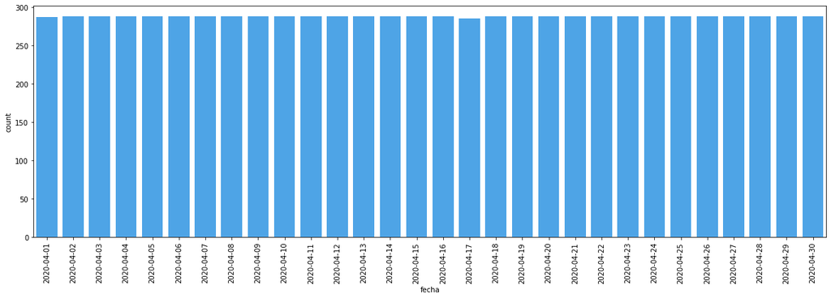

```python
display_markdown('#### Cantidad de registros por día para un mes en particular:')

_ds_april = _ds_energia[(_ds_energia['fecha'] > '2020-04-01 00:00:00') & (_ds_energia['fecha'] <= '2020-04-30 23:59:59')]

#april_count = _ds_april.groupby(_ds_april['fecha'].dt.date).size().reset_index(name='Count')
#april_count

plt.figure(figsize=(20,6))
sns.countplot(data=_ds_april, x=_ds_april['fecha'].dt.date, color=BLUE)
plt.xticks(rotation=90)
```

### Tipos de variables

```python
data_types = _ds_energia.dtypes
data_types = pd.DataFrame(data_types)
data_types = data_types.rename(columns = {0:'ReadingDataType'})
data_types.index.names = ['FieldName']
data_types
```

[output not shown]

### Min, Max, Media, Mediana, Duplicados

```python
# Descripción
_ds_energia.describe(include = 'all')
```

|  | fecha | ta | sa | ra | vab | vca | vbc | kwatts | potencia |
| --- | --- | --- | --- | --- | --- | --- | --- | --- | --- |
| count | 44363 | 44363.000 | 44362.000 | 44345.000 | 35331.000 | 35331.000 | 35331.000 | 43462.000 | 44209.000 |
| unique | 44363 | nan | nan | nan | nan | nan | nan | nan | nan |
| top | 2019-12-13 03:45:00 | nan | nan | nan | nan | nan | nan | nan | nan |
| freq | 1 | nan | nan | nan | nan | nan | nan | nan | nan |
| first | 2019-12-03 20:45:00 | nan | nan | nan | nan | nan | nan | nan | nan |
| last | 2020-05-07 11:10:00 | nan | nan | nan | nan | nan | nan | nan | nan |
| mean | NaN | 8.600 | 8.668 | 8.883 | 345576.725 | 345882.080 | 346002.556 | -280996476.649 | 0.445 |
| std | NaN | 9.797 | 9.859 | 10.043 | 789079.359 | 789359.073 | 789471.629 | 724218113.835 | 0.746 |
| min | NaN | 0.000 | 0.000 | 0.000 | 0.000 | 0.000 | 0.000 | -2147483647.000 | -0.980 |
| 25% | NaN | 0.000 | 0.000 | 0.000 | 35.410 | 37.370 | 36.270 | -3927.000 | 0.000 |
| 50% | NaN | 3.000 | 3.000 | 4.000 | 36.710 | 38.780 | 37.430 | 2925.000 | 0.920 |
| 75% | NaN | 17.000 | 17.000 | 17.000 | 44.835 | 46.370 | 44.410 | 3973.000 | 0.960 |
| max | NaN | 37.000 | 37.000 | 37.000 | 2147483.650 | 2147483.650 | 2147483.650 | 7019.000 | 0.990 |

```python
# Para visualizar mejor los rangos y su mediana

ranges_median = pd.concat([_ds_energia.min(), _ds_energia.max(), _ds_energia.median(), _ds_energia.mean()], axis=1)
ranges_median.columns = ['Minimo', 'Maximo', 'Mediana', 'Media']
print("Rango y mediana de las variables: ")
display(ranges_median)
```

```
Rango y mediana de las variables:
```

|  | Minimo | Maximo | Mediana | Media |
| --- | --- | --- | --- | --- |
| fecha | 2019-12-03 20:45:00 | 2020-05-07 11:10:00 | nan | nan |
| ta | 0.000 | 37.000 | 3.000 | 8.600 |
| sa | 0.000 | 37.000 | 3.000 | 8.668 |
| ra | 0.000 | 37.000 | 4.000 | 8.883 |
| vab | 0.000 | 2147483.650 | 36.710 | 345576.725 |
| vca | 0.000 | 2147483.650 | 38.780 | 345882.080 |
| vbc | 0.000 | 2147483.650 | 37.430 | 346002.556 |
| kwatts | -2147483647.000 | 7019.000 | 2925.000 | -280996476.649 |
| potencia | -0.980 | 0.990 | 0.920 | 0.445 |

### Graficos

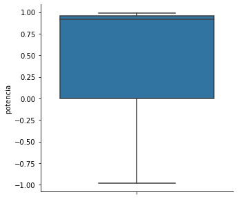

```python
plt.figure(figsize=(5,5))
sns.boxplot(y=_ds_energia['potencia'])
sns.despine()
```

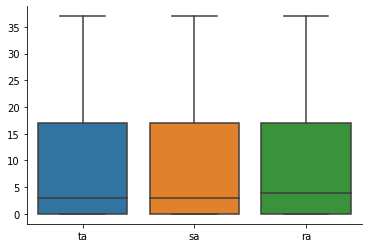

```python
ds_amperes = _ds_energia[['ta','sa','ra']]
sns.boxplot(data=ds_amperes)
sns.despine()
```

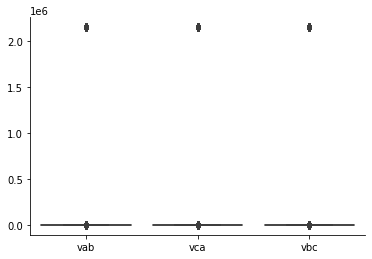

```python
ds_tensiones = _ds_energia[['vab','vca','vbc']]
sns.boxplot(data=ds_tensiones)
sns.despine()
```

### Analisis de valores negativos

```python
ds_fases_neg = _ds_energia[(_ds_energia['kwatts'] < 0.0)]
ds_fases_neg_count = ds_fases_neg.shape[0]
ds_fases_neg_potencia_count = ds_fases_neg[ds_fases_neg.potencia > 0.0].shape[0]

display_markdown("- Cantidad de registros de **Kwatts 3 fases** de Potencia Total con valores negativos: {}".format(ds_fases_neg_count))
display_markdown("- Cantidad de registros de **Kwatts 3 fases** de Potencia Total con valores negativos y **Factor de Potencia** en positivos: {}".format(ds_fases_neg_potencia_count))
display_markdown("> _Por lo tanto, para todos los Kwatts 3 fases que son negativos, tambien lo será el Factor de Potencia_")

_ds_potencia_neg = _ds_energia[(_ds_energia['potencia'] < 0.0)]
_ds_potencia_neg_count = _ds_potencia_neg.shape[0]
_ds_potencia_neg_kwatts_count = _ds_potencia_neg[_ds_potencia_neg['kwatts'] > 0.0].shape[0]

display_markdown("- Cantidad de registros de **Factor de Potencia** con valores negativos: {}".format(_ds_potencia_neg_count))
display_markdown("- Cantidad de registros de **Factor de Potencia** con valores negativos y **Kwatts 3 fases** en positivos: {}".format(_ds_potencia_neg_kwatts_count))
display_markdown("> _Observamos que los {} valores positivos de **Kwatts 3 fases** anteriores son cercanos al cero: {}_".format(_ds_potencia_neg_kwatts_count, _ds_potencia_neg[_ds_potencia_neg['kwatts'] > 0.0].kwatts.tolist()))
```

- Cantidad de registros de **Kwatts 3 fases** de Potencia Total con valores negativos: 14444

- Cantidad de registros de **Kwatts 3 fases** de Potencia Total con valores negativos y **Factor de Potencia** en positivos: 0

- Cantidad de registros de **Factor de Potencia** con valores negativos: 8802

- Cantidad de registros de **Factor de Potencia** con valores negativos y **Kwatts 3 fases** en positivos: 8

> *Observamos que los 8 valores positivos de **Kwatts 3 fases** anteriores son cercanos al cero: [13.0, 9.0, 9.0, 76.0, 4.0, 3.0, 2.0, 22.0]*

```python
display_markdown('#### Tabla resumen de negativos:')
_ds_exclude_date = _ds_energia.loc[:, _ds_energia.columns != 'fecha']
_ds_exclude_date[_ds_exclude_date < 0.0].count().reset_index(name='Count')
```

Tabla resumen de negativos:

|  | index | Count |
| --- | --- | --- |
| 0 | ta | 0 |
| 1 | sa | 0 |
| 2 | ra | 0 |
| 3 | vab | 0 |
| 4 | vca | 0 |
| 5 | vbc | 0 |
| 6 | kwatts | 14444 |
| 7 | potencia | 8802 |

### Valores NaN y Cero

```python
display_markdown('##### Cantidad de ceros y Nan para Kwatts 3 fases:')

display_markdown("- Valores NaN de Kwatts 3 fases: **{}**".format(_ds_energia[(_ds_energia['kwatts'].isna())].kwatts.shape[0]))
display_markdown("- Valores cero de Kwatts 3 fases: **{}**".format(_ds_energia[(_ds_energia['kwatts'] == 0.0)].kwatts.shape[0]))
```

Cantidad de ceros y Nan para Kwatts 3 fases:

- Valores NaN de Kwatts 3 fases: **901**

- Valores cero de Kwatts 3 fases: **241**

```python
_ds_amperes_nan = _ds_energia[_ds_energia.sa.isna() | _ds_energia.ta.isna() | _ds_energia.ra.isna() ]

display_markdown('##### Cantidad de NaN para cada fase:')
display_markdown("- Amper fase T-A: **{}**".format(_ds_amperes_nan.ta.count()))
display_markdown("- Amper fase S-A: **{}**".format(_ds_amperes_nan.sa.count()))
display_markdown("- Amper fase R-A: **{}**".format(_ds_amperes_nan.ra.count()))


_ds_amperes_zero = _ds_energia[(_ds_energia.sa == 0.0) & (_ds_energia.ta == 0.0) & (_ds_energia.ra == 0.0)]

display_markdown('##### Cantidad de ceros para cada fase:')
display_markdown("- Amper fase T-A: **{}**".format(_ds_amperes_zero.ta.count()))
display_markdown("- Amper fase S-A: **{}**".format(_ds_amperes_zero.sa.count()))
display_markdown("- Amper fase R-A: **{}**".format(_ds_amperes_zero.ra.count()))
```

Cantidad de NaN para cada fase:

- Amper fase T-A: **18**

- Amper fase S-A: **17**

- Amper fase R-A: **0**

Cantidad de ceros para cada fase:

- Amper fase T-A: **22031**

- Amper fase S-A: **22031**

- Amper fase R-A: **22031**

```python
display_markdown('#### Tabla resumen de NaN:')

_ds_energia.isnull().sum().reset_index(name='Count')
```

Tabla resumen de NaN:

|  | index | Count |
| --- | --- | --- |
| 0 | fecha | 0 |
| 1 | ta | 0 |
| 2 | sa | 1 |
| 3 | ra | 18 |
| 4 | vab | 9032 |
| 5 | vca | 9032 |
| 6 | vbc | 9032 |
| 7 | kwatts | 901 |
| 8 | potencia | 154 |

```python
display_markdown('#### Tabla resumen de ceros:')

_ds_energia[(_ds_energia == 0.0)].count().reset_index(name='Count')
```

Tabla resumen de ceros:

|  | index | Count |
| --- | --- | --- |
| 0 | fecha | 0 |
| 1 | ta | 22057 |
| 2 | sa | 22058 |
| 3 | ra | 22036 |
| 4 | vab | 121 |
| 5 | vca | 108 |
| 6 | vbc | 106 |
| 7 | kwatts | 241 |
| 8 | potencia | 5903 |

### Cortes de energía

Observaciones

- Tomamos los valores de **Kwatts 3 fases** menores a 100 como cero.

- Se observa que los cortes de energia se presentaron en los meses de verano.

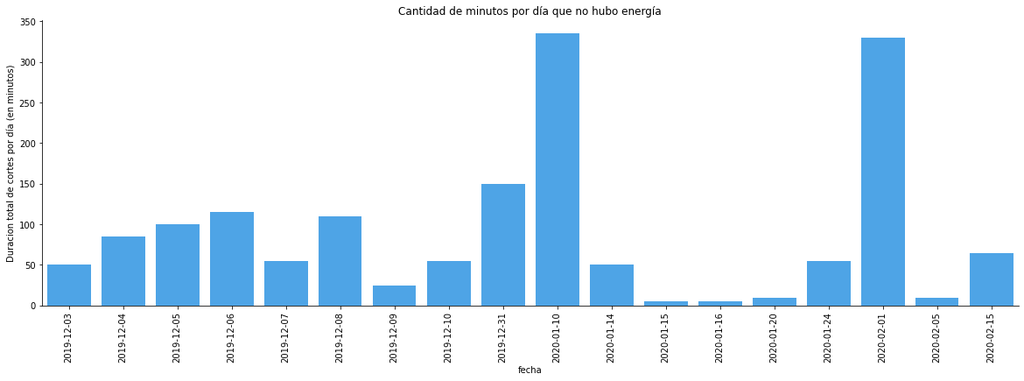

```python
_ds_cortes = _ds_energia[(_ds_energia['kwatts'].abs() < 100.0)]

_ds_cortes_count = _ds_cortes.groupby(_ds_cortes['fecha'].dt.date).size().reset_index(name='Count')
_ds_cortes_count.Count = _ds_cortes_count.Count*5
_ds_cortes_count

plt.figure(figsize=(20,6))
sns.barplot(x="fecha", y="Count", data=_ds_cortes_count, color=BLUE)
plt.xticks(rotation=90)
plt.ylabel('Duracion total de cortes por día (en minutos)')
plt.title('Cantidad de minutos por día que no hubo energía')
sns.despine()

display_markdown('#### Observaciones')
display_markdown('- Tomamos los valores de **Kwatts 3 fases** menores a 100 como cero.')
display_markdown('- Se observa que los cortes de energia se presentaron en los meses de verano.')
```

```python
print('Si queremos ver en números:')
_ds_cortes_count.columns = ['Fecha','Total minutos de corte']
_ds_cortes_count
```

```
Si queremos ver en números:
```

|  | Fecha | Total minutos de corte |
| --- | --- | --- |
| 0 | 2019-12-03 | 50 |
| 1 | 2019-12-04 | 85 |
| 2 | 2019-12-05 | 100 |
| 3 | 2019-12-06 | 115 |
| 4 | 2019-12-07 | 55 |
| 5 | 2019-12-08 | 110 |
| 6 | 2019-12-09 | 25 |
| 7 | 2019-12-10 | 55 |
| 8 | 2019-12-31 | 150 |
| 9 | 2020-01-10 | 335 |
| 10 | 2020-01-14 | 50 |
| 11 | 2020-01-15 | 5 |
| 12 | 2020-01-16 | 5 |
| 13 | 2020-01-20 | 10 |
| 14 | 2020-01-24 | 55 |
| 15 | 2020-02-01 | 330 |
| 16 | 2020-02-05 | 10 |
| 17 | 2020-02-15 | 65 |

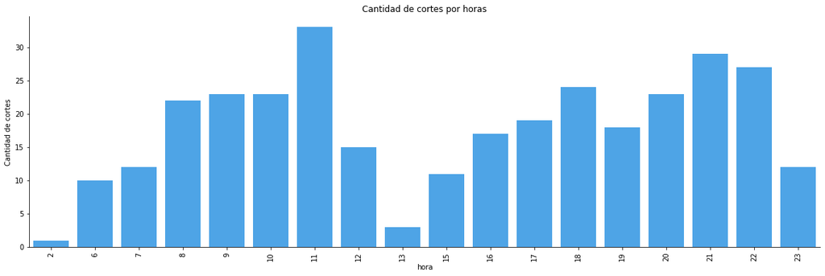

```python
_ds_cortes_by_hours = _ds_cortes.groupby(_ds_cortes['fecha'].dt.hour).size().reset_index(name='Count')
_ds_cortes_by_hours.columns = ['hora', 'count']

plt.figure(figsize=(20,6))
sns.barplot(x="hora", y="count", data=_ds_cortes_by_hours, color=BLUE)
plt.xticks(rotation=90)
plt.ylabel('Cantidad de cortes')
plt.title('Cantidad de cortes por horas')
sns.despine()
```

```python
display_markdown('Podemos observar en orden los horarios con mayores cantidades de cortes:')

_ds_cortes_by_hours.column = ['Hora', 'Cantidad de Cortes']
_ds_cortes_by_hours.sort_values(by='count', ascending=False)
```

Podemos observar en orden los horarios con mayores cantidades de cortes:

|  | hora | count |
| --- | --- | --- |
| 6 | 11 | 33 |
| 15 | 21 | 29 |
| 16 | 22 | 27 |
| 12 | 18 | 24 |
| 14 | 20 | 23 |
| 4 | 9 | 23 |
| 5 | 10 | 23 |
| 3 | 8 | 22 |
| 11 | 17 | 19 |
| 13 | 19 | 18 |
| 10 | 16 | 17 |
| 7 | 12 | 15 |
| 17 | 23 | 12 |
| 2 | 7 | 12 |
| 9 | 15 | 11 |
| 1 | 6 | 10 |
| 8 | 13 | 3 |
| 0 | 2 | 1 |

```python
display_markdown('Si agrupamos por rangos de horas:')
_ds_cortes_by_hours.groupby(pd.cut(_ds_cortes_by_hours["hora"], pd.IntervalIndex.from_tuples([(0, 6), (6, 12), (12, 18), (18, 24)]))).sum()
```

Si agrupamos por rangos de horas:

| hora | hora | count |
| --- | --- | --- |
| (0, 6] | 8 | 11 |
| (6, 12] | 57 | 128 |
| (12, 18] | 79 | 74 |
| (18, 24] | 105 | 109 |

```python
# Se genera un dataset con la duracion de los cortes medidos en minutos

_ds_duracion_cortes = pd.DataFrame(columns=['fecha', 'duracion'])

i = 1

datetime_corte_actual = None

while i < len(_ds_cortes):
    medicion_corte_anterior = _ds_cortes.iloc[i-1].fecha
    medicion_corte_actual = _ds_cortes.iloc[i].fecha

    if i==1:
        #print('nuevo corte {}'.format(medicion_corte_anterior))
        datetime_corte_actual = medicion_corte_anterior
        _ds_duracion_cortes = _ds_duracion_cortes.append({'fecha': datetime_corte_actual, 'duracion': 5}, ignore_index=True)

    if medicion_corte_actual == medicion_corte_anterior + dt.timedelta(minutes=5):
        _ds_duracion_cortes.loc[_ds_duracion_cortes.fecha == datetime_corte_actual, 'duracion'] += 5
        #_ds_duracion_cortes['duracion'] = _ds_duracion_cortes.apply(lambda x: x.duracion+5 if x['fecha']==pd.Timestamp(datetime_corte_actual) else 0, axis=1)

        i=i+1
    else:
        datetime_corte_actual = medicion_corte_actual
        _ds_duracion_cortes = _ds_duracion_cortes.append({'fecha': datetime_corte_actual, 'duracion': 5}, ignore_index=True)

        i=i+1


_ds_duracion_cortes.shape
```

```
(90, 2)
```

```python
display_markdown('### Duracioón de los cortes de energia (en minutos):')

_ds_duracion_cortes_ranges_median = pd.concat([_ds_duracion_cortes.min(), _ds_duracion_cortes.max(), _ds_duracion_cortes.median(), _ds_duracion_cortes.mean()], axis=1)
_ds_duracion_cortes_ranges_median.columns = ['Minimo', 'Maximo', 'Mediana', 'Media']
print("Rango y mediana de las variables: ")
display(_ds_duracion_cortes_ranges_median)
```

Duracioón de los cortes de energia (en minutos):

```
Rango y mediana de las variables:
```

|  | Minimo | Maximo | Mediana | Media |
| --- | --- | --- | --- | --- |
| fecha | 2019-12-03 21:00:00 | 2020-02-15 15:45:00 | nan | nan |
| duracion | 5 | 330 | 5.000 | 17.889 |

```python
display_markdown('### Duracioón de los cortes de energia (en minutos) por mes:')
display_markdown('12=diciembre, 1=enero, 2=febrero')

_ds_duracion_cortes.groupby(_ds_duracion_cortes['fecha'].dt.month).sum()
```

Duracioón de los cortes de energia (en minutos) por mes:

12=diciembre, 1=enero, 2=febrero

| fecha | duracion |
| --- | --- |
| 1 | 460 |
| 2 | 405 |
| 12 | 745 |

```python
from IPython.display import display, Markdown


def display_markdown(*args, **kwargs):
    return display(Markdown(*args, **kwargs))

# Importación de las librerías necesarias
import numpy as np
import pandas as pd
import matplotlib as mpl
mpl.get_cachedir()
import matplotlib.pyplot as plt
%matplotlib inline
import seaborn as sns
import datetime as dt
import warnings
import scipy.stats
import matplotlib.lines as mlines
import matplotlib.patches as mpatches

pd.set_option('display.max_columns', 150)
pd.set_option('display.max_rows', 150)
pd.set_option('max_colwidth', 151)
#pd.set_option('display.float_format', lambda x: '%.3f' % x)
warnings.filterwarnings('ignore')

#Parsing auxiliar
dateparse = lambda x: dt.datetime.strptime(x, '%Y-%m-%d %H:%M:%S')
```

```python
### Análisis estadístico de los datos
# Carga de datos
_ds_clima = pd.read_csv('https://github.com/alaain04/diplodatos/raw/master/data/clima.csv',parse_dates=['time'],date_parser=dateparse)
_ds_energia = pd.read_csv('https://raw.githubusercontent.com/alaain04/diplodatos/master/data/distribucion.csv',
                          dtype={'Amper fase T-A': float},
                          parse_dates=['Fecha'],
                          date_parser=dateparse,
                          float_precision='round_trip')

# Ordenamos los datos del dataset de energia por fecha y hacemos positivos los valores negativos
ds_energia_tomerge = _ds_energia.sort_values(by='Fecha').reset_index()
ds_energia_tomerge.columns = ['indice','time','faseTA','faseSA','faseRA','Vab','Vca','Vbc','Kwatts','potencia']
ds_energia_tomerge[['faseTA','faseSA','faseRA','Vab','Vca','Vbc','Kwatts','potencia']]=np.abs(ds_energia_tomerge[['faseTA','faseSA','faseRA','Vab','Vca','Vbc','Kwatts','potencia']])
ds_energia_tomerge.drop(columns=['indice'], inplace=True)
# Ordenamos los datos del dataset de clima y nos quedamos con las variables relevantes
ds_clima_tomerge = _ds_clima.sort_values(by='time').reset_index()
ds_clima_tomerge = ds_clima_tomerge[['time','temperature','windspeed']]

# Unimos la información de ambos datasets
df1 = ds_energia_tomerge
df2 = ds_clima_tomerge
ds_total = pd.merge(df1,df2, on='time', how='outer')
ds_total.sort_values(by='time', inplace=True)
ds_total = ds_total.reset_index().drop(columns='index')
# Primer análisis de los estadísticos de las variables
display(ds_total.describe(include='all'))
```

|  | time | faseTA | faseSA | faseRA | Vab | Vca | Vbc | Kwatts | potencia | temperature | windspeed |
| --- | --- | --- | --- | --- | --- | --- | --- | --- | --- | --- | --- |
| count | 44943 | 44363.000000 | 44362.000000 | 44345.000000 | 3.533100e+04 | 3.533100e+04 | 3.533100e+04 | 4.346200e+04 | 44209.000000 | 3001.000000 | 2999.000000 |
| unique | 44943 | NaN | NaN | NaN | NaN | NaN | NaN | NaN | NaN | NaN | NaN |
| top | 2020-03-28 03:10:00 | NaN | NaN | NaN | NaN | NaN | NaN | NaN | NaN | NaN | NaN |
| freq | 1 | NaN | NaN | NaN | NaN | NaN | NaN | NaN | NaN | NaN | NaN |
| first | 2019-11-01 00:00:00 | NaN | NaN | NaN | NaN | NaN | NaN | NaN | NaN | NaN | NaN |
| last | 2020-05-13 21:00:00 | NaN | NaN | NaN | NaN | NaN | NaN | NaN | NaN | NaN | NaN |
| mean | NaN | 8.599689 | 8.667869 | 8.883414 | 3.455767e+05 | 3.458821e+05 | 3.460026e+05 | 2.810014e+08 | 0.807501 | 23.018294 | 6.595599 |
| std | NaN | 9.797469 | 9.859359 | 10.042508 | 7.890794e+05 | 7.893591e+05 | 7.894716e+05 | 7.242162e+08 | 0.320525 | 5.485819 | 3.795323 |
| min | NaN | 0.000000 | 0.000000 | 0.000000 | 0.000000e+00 | 0.000000e+00 | 0.000000e+00 | 0.000000e+00 | 0.000000 | 4.700000 | 0.400000 |
| 25% | NaN | 0.000000 | 0.000000 | 0.000000 | 3.541000e+01 | 3.737000e+01 | 3.627000e+01 | 3.173000e+03 | 0.890000 | 19.700000 | 3.600000 |
| 50% | NaN | 3.000000 | 3.000000 | 4.000000 | 3.671000e+01 | 3.878000e+01 | 3.743000e+01 | 3.959500e+03 | 0.930000 | 22.700000 | 5.800000 |
| 75% | NaN | 17.000000 | 17.000000 | 17.000000 | 4.483500e+01 | 4.637000e+01 | 4.441000e+01 | 5.028750e+03 | 0.960000 | 26.700000 | 9.000000 |
| max | NaN | 37.000000 | 37.000000 | 37.000000 | 2.147484e+06 | 2.147484e+06 | 2.147484e+06 | 2.147484e+09 | 0.990000 | 37.600000 | 25.200000 |

```python
## Eliminamos los outliers de las variables del dataset de energía
# Consideramos outliers a los valores que se encuentre a más de 2 veces un intervalo de confianza CI de la mediana.
# (Definimos al CI como la diferencia entre los cuantiles de 75% y el de 25%)
# En caso de ser un valor mayor a la mediana + 2*CI, consideramos que es un error en la medicion y eliminamos ese valor
# En caso de ser un valor menor a la mediana - 2*CI, consideramos que se muestra un corte del servicio y lo reemplazamos por 0 para simplificar el análisis.
interesting_col = ['faseTA','faseSA','faseRA','Vab','Vca','Vbc','Kwatts']
for col in interesting_col:
  CI =  (ds_total[col].quantile(0.75)-ds_total[col].quantile(0.25))
  ds_total[col] = ds_total[col].mask((ds_total[col] - ds_total[col].median()) > 2*CI , np.nan)
  ds_total[col] = ds_total[col].mask((ds_total[col].median() - ds_total[col]) > 2*CI , 0)


# Segundo análisis de los estadísticos de las variables, luego de haber eliminado outliers
display(ds_total.describe(include='all'))
```

|  | time | faseTA | faseSA | faseRA | Vab | Vca | Vbc | Kwatts | potencia | temperature | windspeed |
| --- | --- | --- | --- | --- | --- | --- | --- | --- | --- | --- | --- |
| count | 44943 | 44363.000000 | 44362.000000 | 44345.000000 | 29535.000000 | 29584.000000 | 28900.000000 | 37773.000000 | 44209.000000 | 3001.000000 | 2999.000000 |
| unique | 44943 | NaN | NaN | NaN | NaN | NaN | NaN | NaN | NaN | NaN | NaN |
| top | 2020-03-28 03:10:00 | NaN | NaN | NaN | NaN | NaN | NaN | NaN | NaN | NaN | NaN |
| freq | 1 | NaN | NaN | NaN | NaN | NaN | NaN | NaN | NaN | NaN | NaN |
| first | 2019-11-01 00:00:00 | NaN | NaN | NaN | NaN | NaN | NaN | NaN | NaN | NaN | NaN |
| last | 2020-05-13 21:00:00 | NaN | NaN | NaN | NaN | NaN | NaN | NaN | NaN | NaN | NaN |
| mean | NaN | 8.599689 | 8.667869 | 8.883414 | 37.931823 | 39.690707 | 38.009518 | 3827.819792 | 0.807501 | 23.018294 | 6.595599 |
| std | NaN | 9.797469 | 9.859359 | 10.042508 | 5.882753 | 5.714567 | 4.986345 | 1048.148636 | 0.320525 | 5.485819 | 3.795323 |
| min | NaN | 0.000000 | 0.000000 | 0.000000 | 0.000000 | 0.000000 | 0.000000 | 0.000000 | 0.000000 | 4.700000 | 0.400000 |
| 25% | NaN | 0.000000 | 0.000000 | 0.000000 | 35.300000 | 37.180000 | 36.110000 | 3059.000000 | 0.890000 | 19.700000 | 3.600000 |
| 50% | NaN | 3.000000 | 3.000000 | 4.000000 | 35.990000 | 38.080000 | 36.840000 | 3759.000000 | 0.930000 | 22.700000 | 5.800000 |
| 75% | NaN | 17.000000 | 17.000000 | 17.000000 | 39.210000 | 41.200000 | 39.000000 | 4506.000000 | 0.960000 | 26.700000 | 9.000000 |
| max | NaN | 37.000000 | 37.000000 | 37.000000 | 55.560000 | 56.780000 | 53.700000 | 7375.000000 | 0.990000 | 37.600000 | 25.200000 |

```python
# Además nos quedamos con el intervalo de tiempo sobre el cual tenemos datos del consumo eléctrico.

indice_ini=ds_energia_tomerge.iloc[0]
indice_fin=ds_energia_tomerge.iloc[-1]

ds_total_new=ds_total

start_new = ds_total_new[ds_total_new['time']==indice_ini[0]].index
end_new   = ds_total_new[ds_total_new['time']==indice_fin[0]].index

ds_total_new = ds_total_new[start_new[0]:end_new[0]]
ds_total_periodico = ds_total_new
```

```python
# Agrupamos los datos en periodos más grande de tiempo facilitar la visualización

ds_total_mean = ds_total_periodico
ds_total_mean.index = pd.PeriodIndex(list(ds_total_periodico['time']), freq='H')
pt_total_mean = ds_total_mean.resample('12H').mean()

pt_total_mean = pt_total_mean.reset_index()
pt_total_mean.columns = ['time','faseTA','faseSA','faseRA','Vab','Vca','Vbc','Kwatts','potencia','temperature','windspeed']

ds_total_new.reset_index(inplace=True)
```

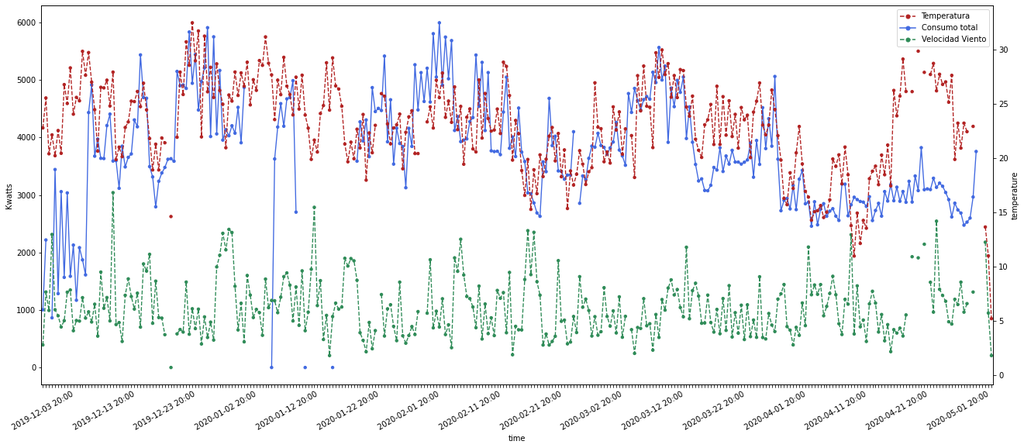

```python
#  Gráfico para comparar las variables
plt.figure(figsize=(22,9))
ax1 = sns.pointplot(x='time',y='Kwatts',data=pt_total_mean,color='royalblue',scale=0.5,linestyles='-')
ax2 = plt.twinx()

ax4 = sns.pointplot(x='time',y='windspeed',data=pt_total_mean, ax=ax2,color='seagreen',scale=0.5,linestyles='--')
ax3 = sns.pointplot(x='time',y='temperature',data=pt_total_mean, ax=ax2,color='firebrick',scale=0.5,linestyles='--')

labels = ax1.get_xticklabels() # get x labels
for i,l in enumerate(labels):
    if(i%20 != 0): labels[i] = '' # skip even labels
ax1.set_xticklabels(labels, rotation=30) # set new labels

red_line = mlines.Line2D( [],[],linestyle='--', color='firebrick', marker='.',
                          markersize=10, label='Temperatura')
blue_line = mlines.Line2D([], [],linestyle='-', color='royalblue', marker='.',
                          markersize=10, label='Consumo total')
green_line = mlines.Line2D([], [],linestyle='--', color='seagreen', marker='.',
                          markersize=10, label='Velocidad Viento')

plt.legend(handles=[red_line, blue_line,green_line])
plt.show()
```

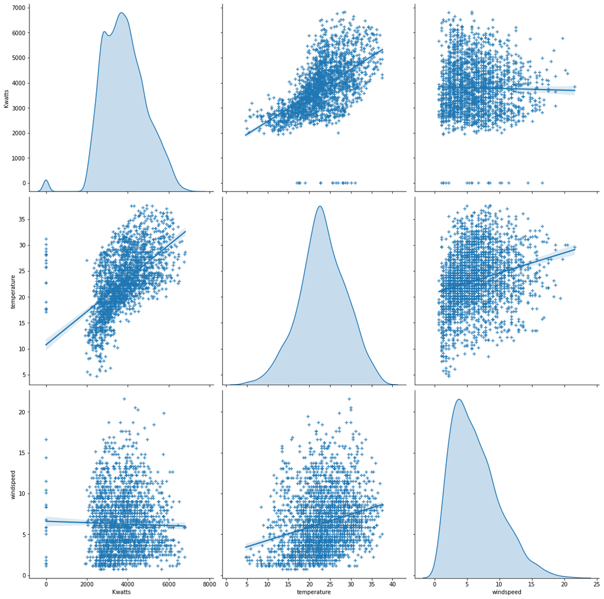

```python
# Análisis de la distribución y correlación de las variables a estudiar (Potencia total, temperatura y velocidad del viento)
sns.pairplot(data=ds_total_new, markers="+",vars=['Kwatts','temperature','windspeed'], height=5,diag_kind="kde",kind = 'reg')
```